# Central Limit Theorem (CLT) and Confidence Intervals

Matthew E. Aiello-Lammens

# Section Goals

- Identify the mathematical relationships between population statistics, sample statistics, and confidence intervals
- Be able to calculate a margin of error and confidence interval
- Define the use of confidence intervals in hypothesis testing

# Central Limit Theorem

In the limit as $n \to \infty$, the probability distribution of means of samples from *any distribution* will approach a normal distribution.

## ASIDE: Population versus sample statistics

We use **sample statistics** to estimate **population statistics**. In most cases in biology, populations are too large to measure population parameters directly. Therefore, we use different **estimators** to calculate the **populations statistics** based on the **sample statistics**.

### Good videos explaining the CLT

- https://youtu.be/lsCc_pS3O28
- https://youtu.be/3SKwerKHbRk

## CLT Example - Working with the Youth Risk Behavior Surveillance System (YRBSS) data

In this lesson, we’re going to explore variation in point estimates and Confidence Intervals. We will largely be following content that can be found in the textbook OpenIntro Statistics by Diez, Barr, and Çetinkaya-Rundel.

We’ll be working with the Youth Risk Behavior Surveillance System (YRBSS). Here, we will start be examining the **full** data set.

### Population Parameters

Let’s begin by loading the data into our environment.

You may need to first install the `openintro` R package

```r
install.packages("openintro")
```

After that, we can load in the data.

```r
library(openintro)
data(yrbss)
```

As with any data set, let’s have a quick look at the data using `summary`.

```r
summary(yrbss)
```

```
##       age           gender             grade             hispanic
##  Min.   :12.00   Length:13583       Length:13583       Length:13583
##  1st Qu.:15.00   Class :character   Class :character   Class :character
##  Median :16.00   Mode  :character   Mode  :character   Mode  :character
##  Mean   :16.16
##  3rd Qu.:17.00
##  Max.   :18.00
##  NA's   :77
##      race               height          weight        helmet_12m
##  Length:13583       Min.   :1.270   Min.   : 29.94   Length:13583
##  Class :character   1st Qu.:1.600   1st Qu.: 56.25   Class :character
##  Mode  :character   Median :1.680   Median : 64.41   Mode  :character
##                     Mean   :1.691   Mean   : 67.91
##                     3rd Qu.:1.780   3rd Qu.: 76.20
##                     Max.   :2.110   Max.   :180.99
##                     NA's   :1004    NA's   :1004
##  text_while_driving_30d physically_active_7d hours_tv_per_school_day
##  Length:13583           Min.   :0.000        Length:13583
##  Class :character       1st Qu.:2.000        Class :character
##  Mode  :character       Median :4.000        Mode  :character
##                         Mean   :3.903
##                         3rd Qu.:7.000
##                         Max.   :7.000
##                         NA's   :273
##  strength_training_7d school_night_hours_sleep
##  Min.   :0.00         Length:13583
##  1st Qu.:0.00         Class :character
##  Median :3.00         Mode  :character
##  Mean   :2.95
##  3rd Qu.:5.00
##  Max.   :7.00
##  NA's   :1176
```

For now, let’s focus on the variable `height`. First, let’s calculate the **population mean** for `height`. Remember, that the population mean is going to be the mean value for the *full* data set.

```r
mean(yrbss$height)
```

```
## [1] NA
```

That’s probably not the answer you were expecting. There must have been students whose data was collected, but their heights weren’t recorded, so a value of *NA* was assigned. In order to ignore these data, we need to add the argument `na.rm = TRUE` to our `mean` call.

```r
mean(yrbss$height, na.rm = TRUE)
```

```
## [1] 1.691241
```

### Sample Parameter Estimates

OK, let’s assume that we could only collect data from a subset of the high school students whose data are in this data set. We can use the data in this subset to **estimate** population level parameters. This subset would be called our **sample**.

We’ll choose a subset at random, but we’ll make it so that everyone in the class gets the same random subset.

```r
set.seed(1981)
yrbss_samp <- yrbss[sample(x = 1:nrow(yrbss), replace = FALSE, size = 10), ]
```

#### Challenge - Breakdown each piece of the command that we are using to get our sample.

To do this, you should make sure to look at the help for `sample`.

Let’s calculate the mean height based on our sample.

```r
mean(yrbss_samp$height, na.rm = TRUE)
```

```
## [1] 1.696667
```

How does it compare to the true mean?

Let’s try increasing our sample size, and see if that makes a difference?

#### Sample size = 100

```r
set.seed(1981)
yrbss_samp <- yrbss[sample(x = 1:nrow(yrbss), replace = FALSE, size = 100), ]
mean(yrbss_samp$height, na.rm = TRUE)
```

```
## [1] 1.684362
```

#### Sample size = 1000

```r
set.seed(1981)
yrbss_samp <- yrbss[sample(x = 1:nrow(yrbss), replace = FALSE, size = 1000), ]
mean(yrbss_samp$height, na.rm = TRUE)
```

```
## [1] 1.682717
```

In general, though not always, as you increase sample size, you get closer to the *true* population values for an estimated parameter.

## Standard Error of the Mean

Let’s imagine the we took *100 different subsets, or **samples**,* from these data, then calculated the mean for each of these samples, and then examined the histogram of these means. The shape of the histogram should prove to be that of a normal distribution.

In order to demonstrate this, we’ll need to use `for` loops.

```r
# start with a vector to store our mean values
samp_means <- c()

# start a for loop the does 100 iterations
for(x in 1:100){
  # get a sample of the data of size 100
  yrbss_samp <- yrbss[sample(x = 1:nrow(yrbss), replace = FALSE, size = 100), ]

  # calulate the mean of this sample
  mean_samp <- mean(yrbss_samp$height, na.rm = TRUE)

  # add this mean to the vector of sample means
  samp_means <- c(samp_means, mean_samp)
}
```

We should now have 100 values in the vector `samp_means`. Let’s look at a histogram of these values.

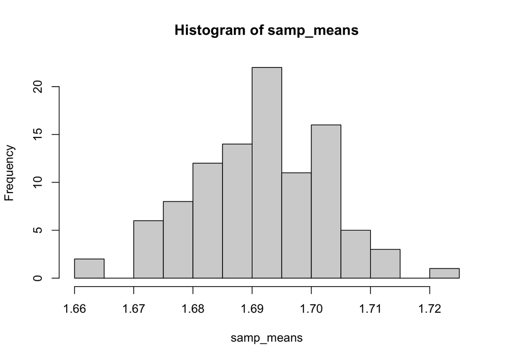

```r
hist(samp_means, breaks = 20)
```

Alright, it’s normalish (i.e., approximately normal), though clearly not perfectly normal.

### Challenge - interpreting this distribution

- What is the mean of the means?
- What is the standard deviation of the means?
- How do the above to values compare to the population values?

```r
mean(yrbss$height, na.rm = TRUE)
mean(samp_means)
sd(yrbss$height, na.rm = TRUE)
sd(samp_means)
```

[output not shown]

The means are very similar, but the sds are not. Why?

The **standard error of the mean** is the standard deviation of the *estimates*.

In practice, we only examine *one*, or a very few, samples. We can still compute the standard error of the mean using the formula:

$$SE = \frac{\sigma}{\sqrt{n}}$$

, where $\sigma$ is the population standard deviation and $n$ is the sample size.

However we almost never know $\sigma$, so we estimate it with our **sample standard deviation** value.

## Confidence Intervals

We just demonstrated that **sample means are approximately normally distributed**. This is a consequence of the **Central Limit Theorem**.

What can we do with this? To start, we can say something about the precision and accuracy of our estimates of the *population* mean based on the *sample* mean.

First, we need to learn about **Z-scores**, which are related to the **Standard Normal Distribution**. The standard normal distribution is a normal distribution with a mean = 0 and a standard deviation = 1. We can convert any observation from normal distribution to it’s equivalent value from a standard normal distribution using:

$$z_i = \frac{y_i - \mu}{\sigma}$$

These are sometimes called *z-scores*.

Using this formula, we can convert a sample mean, $\bar{y}$, into its corresponding value from a standard normal using:

$$z = \frac{\bar{y} - \mu}{SE}$$

where the denominator is the standard error of the mean (see above).

We can use this information to estimate how confident we are that are sample mean is a good representation of the *true* population mean. Again, we are doing this by taking advantage of the fact that we know the sample means are *normally distributed*. We calculate the range in which 95% of the sample mean values fall.

In mathematical terms, this looks like:

$$P\{\bar{y} - 1.96 \times SE \leq \mu \leq \bar{y} + 1.96 \times SE \} =
0.95$$

**VERY IMPORTANT:** The probability statement here is about the *interval*, not $\mu$. $\mu$ is not a random variable; it is fixed. What we are saying is that there is 95% confidence that this interval includes the population mean, $\mu$.

### Unknown $\sigma$ (and $SE$)

As noted above, we rarely know $\sigma$, so we cannot calculate $SE$ exactly. So what *can* we do?

which is no longer standard normal distributed, but rather *t* distributed. We’ll learn more about this distribution later!

### Calculating Confidence Intervals

Let’s calculate the Confidence Interval for our estimate of mean height, using our very first sample of the yrbss data.

First, get the sample again.

```r
set.seed(1981)
yrbss_samp <- yrbss[sample(x = 1:nrow(yrbss), replace = FALSE, size = 10), ]
```

Calculate our sample means.

```r
mean_yrbss_samp <- mean(yrbss_samp$height, na.rm = TRUE)
```

Now, let’s calculate Standard Error.

```r
se_yrbss_samp <- sd(yrbss_samp$height, na.rm = TRUE) / sqrt(nrow(yrbss_samp))
```

Now, calculate our 95% Confidence Interval.

```r
CI_yrbss_upper <- mean_yrbss_samp + (1.96*se_yrbss_samp)
CI_yrbss_lower <- mean_yrbss_samp - (1.96*se_yrbss_samp)
```

Does our Confidence Interval contain the *true* population mean?

#### Challenge - effect of sample size

What happens to the Confidence Interval if you increase the sample size to 100?